# Lab 4: PCA

Author

Nadav K

```r
library(tidyverse)
library(here)
library(ggfortify) # For PCA biplot
```

# Principal components analysis (PCA)

Principal components analysis is an ordination method allowing us to glean as much about our multivariate data as possible in a simplified number of dimensions.

Here, we’ll use [data from the Human Development Index](https://hdr.undp.org/data-center). Quick overview of the HDI:

> The Human Development Index (HDI) is a summary measure of average achievement in key dimensions of human development: a long and healthy life, being knowledgeable and having a decent standard of living. The HDI is the geometric mean of normalized indices for each of the three dimensions.

> The health dimension is assessed by life expectancy at birth, the education dimension is measured by mean of years of schooling for adults aged 25 years and more and expected years of schooling for children of school entering age. The standard of living dimension is measured by gross national income per capita. The HDI uses the logarithm of income, to reflect the diminishing importance of income with increasing GNI. The scores for the three HDI dimension indices are then aggregated into a composite index using geometric mean. Refer to Technical notes for more details.

Load in the data using `read_csv`. Perform some exploratory analysis on the data to get a better grasp of the structure. What do we need for pca to work? What variable needs to be transformed according to the information presented above?

```r
# import data
data = read_csv(here("data","hdi_clean.csv"))

# explore data!
summary(data)
```

```
     iso3             country            hdicode             le_2021
 Length:152         Length:152         Length:152         Min.   :52.53
 Class :character   Class :character   Class :character   1st Qu.:65.59
 Mode  :character   Mode  :character   Mode  :character   Median :72.05
                                                          Mean   :71.54
                                                          3rd Qu.:77.16
                                                          Max.   :84.78
    eys_2021         mys_2021        gnipc_2021       ineq_le_2021
 Min.   : 5.543   Min.   : 2.115   Min.   :  731.8   Min.   : 1.954
 1st Qu.:11.422   1st Qu.: 6.321   1st Qu.: 4609.4   1st Qu.: 4.290
 Median :13.768   Median : 9.430   Median :13010.7   Median : 9.255
 Mean   :13.658   Mean   : 9.056   Mean   :21016.0   Mean   :12.752
 3rd Qu.:15.830   3rd Qu.:11.903   3rd Qu.:32860.9   3rd Qu.:20.076
 Max.   :21.055   Max.   :14.091   Max.   :90918.6   Max.   :39.606
    gii_2021         mf_2021       co2_prod_2021           lat
 Min.   :0.0130   Min.   : 0.470   Min.   : 0.02766   Min.   :-41.817
 1st Qu.:0.1492   1st Qu.: 4.777   1st Qu.: 0.72189   1st Qu.:  7.753
 Median :0.3340   Median :10.735   Median : 2.53443   Median : 23.942
 Mean   :0.3365   Mean   :15.254   Mean   : 4.47228   Mean   : 22.208
 3rd Qu.:0.5095   3rd Qu.:18.983   3rd Qu.: 6.05207   3rd Qu.: 41.359
 Max.   :0.8200   Max.   :85.700   Max.   :37.01945   Max.   : 64.882
```

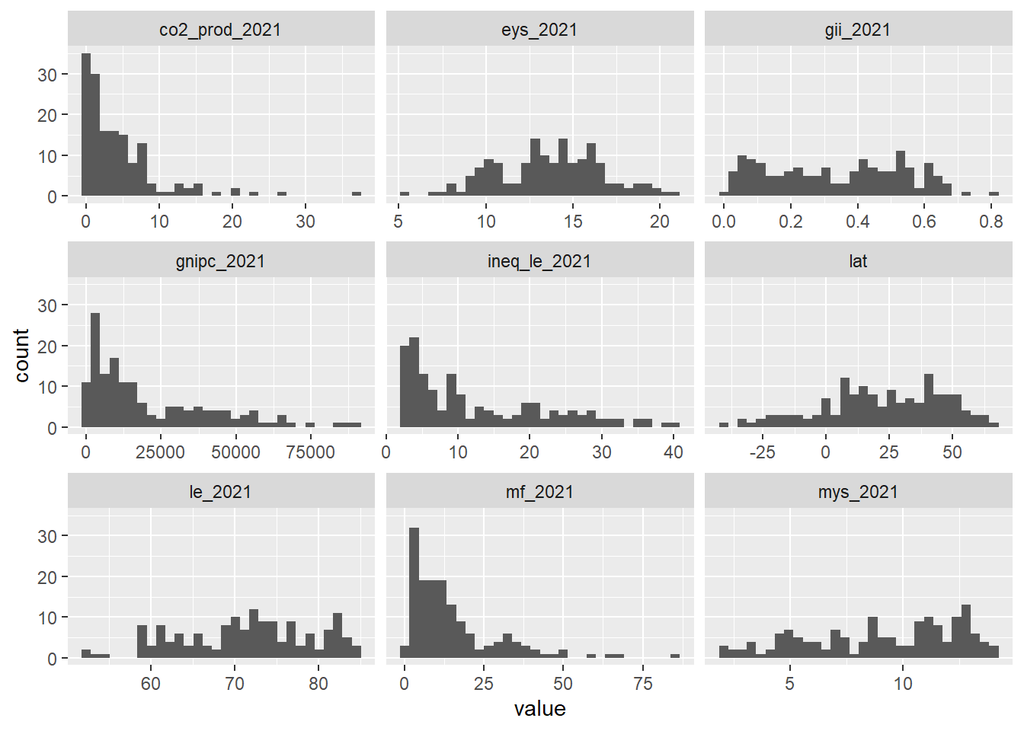

```r
hdi_data_long <- data %>%
  pivot_longer(names_to = 'name', values_to = 'value', where(is.numeric))

ggplot(hdi_data_long, aes(x = value)) +
  geom_histogram() +
  facet_wrap(~ name, scales = 'free_x')
```

```r
hdi_data = data |>
  drop_na() |>
  mutate(gnipc_2021 = log10(gnipc_2021),
         hdicode=factor(hdicode,levels=c("Low","Medium","High","Very High")))
summary(hdi_data)
```

```
     iso3             country               hdicode      le_2021
 Length:152         Length:152         Low      :28   Min.   :52.53
 Class :character   Class :character   Medium   :32   1st Qu.:65.59
 Mode  :character   Mode  :character   High     :33   Median :72.05
                                       Very High:59   Mean   :71.54
                                                      3rd Qu.:77.16
                                                      Max.   :84.78
    eys_2021         mys_2021        gnipc_2021     ineq_le_2021
 Min.   : 5.543   Min.   : 2.115   Min.   :2.864   Min.   : 1.954
 1st Qu.:11.422   1st Qu.: 6.321   1st Qu.:3.664   1st Qu.: 4.290
 Median :13.768   Median : 9.430   Median :4.114   Median : 9.255
 Mean   :13.658   Mean   : 9.056   Mean   :4.066   Mean   :12.752
 3rd Qu.:15.830   3rd Qu.:11.903   3rd Qu.:4.517   3rd Qu.:20.076
 Max.   :21.055   Max.   :14.091   Max.   :4.959   Max.   :39.606
    gii_2021         mf_2021       co2_prod_2021           lat
 Min.   :0.0130   Min.   : 0.470   Min.   : 0.02766   Min.   :-41.817
 1st Qu.:0.1492   1st Qu.: 4.777   1st Qu.: 0.72189   1st Qu.:  7.753
 Median :0.3340   Median :10.735   Median : 2.53443   Median : 23.942
 Mean   :0.3365   Mean   :15.254   Mean   : 4.47228   Mean   : 22.208
 3rd Qu.:0.5095   3rd Qu.:18.983   3rd Qu.: 6.05207   3rd Qu.: 41.359
 Max.   :0.8200   Max.   :85.700   Max.   :37.01945   Max.   : 64.882
```

Run the pca using the `prcomp` function. What extra argument do we need to include? Make sure to select only the numeric columns for the pca

```r
hdi_pca <- hdi_data %>%
  select(where(is.numeric)) %>%
  prcomp(scale=TRUE)
```

Examine the structure of the hdi_pca object. What do you think each piece means? Use documentation to help you understand the output.

```r
# See the loadings (weighting for each principal component)
hdi_pca$rotation
```

```
                     PC1         PC2         PC3          PC4         PC5
le_2021        0.3649211 -0.12004549  0.12009976  0.083521230 -0.58423167
eys_2021       0.3495504 -0.09325323  0.35282835  0.026778635  0.10800225
mys_2021       0.3511427 -0.15666883  0.12235348 -0.261198616  0.67458269
gnipc_2021     0.3782329  0.07207106  0.07924589  0.012972178  0.08139389
ineq_le_2021  -0.3653434  0.17207076 -0.14244025  0.160438566  0.38878424
gii_2021      -0.3732759  0.14527265 -0.03178634 -0.009464272 -0.07905579
mf_2021        0.2982557  0.51332123 -0.08862141  0.741498763  0.12873922
co2_prod_2021  0.2547901  0.66151175 -0.34967674 -0.577164962 -0.10103402
lat            0.2271576 -0.44197803 -0.82970521  0.123061772  0.03372572
                      PC6          PC7         PC8         PC9
le_2021       -0.11322592  0.069259631  0.08663452  0.68159572
eys_2021       0.81139179  0.153527549 -0.22244403 -0.02898662
mys_2021      -0.37705287  0.127418468 -0.22223042  0.32573934
gnipc_2021    -0.07746424  0.405349849  0.76551962 -0.28695471
ineq_le_2021   0.33808000 -0.089737387  0.43224185  0.57493388
gii_2021      -0.02613720  0.872710758 -0.24376070  0.10239465
mf_2021       -0.13587859 -0.007325314 -0.23255339 -0.02644139
co2_prod_2021  0.14457956 -0.050861743 -0.06611082  0.06342154
lat            0.16219185  0.137007247 -0.05387445 -0.01956683
```

```r
summary(hdi_pca)
```

```
Importance of components:
                          PC1    PC2     PC3     PC4    PC5     PC6     PC7
Standard deviation     2.5359 0.9295 0.84153 0.57697 0.5074 0.40677 0.31983
Proportion of Variance 0.7145 0.0960 0.07869 0.03699 0.0286 0.01838 0.01137
Cumulative Proportion  0.7145 0.8105 0.88923 0.92622 0.9548 0.97320 0.98457
                           PC8     PC9
Standard deviation     0.28205 0.24356
Proportion of Variance 0.00884 0.00659
Cumulative Proportion  0.99341 1.00000
```

What can we say about the contributions of these variables to PC1, PC2, and PC3? - PC1 is 71%, PC2 is 9.6%, keep the first 2 to get to 81% variance! ## Scree Plots

Let’s make the screeplot by hand. First, what is the variable of interest on the y-axis and x-axis in a screeplot? How do we extract this information from the PCA object?

Create a dataframe with the necessary indgreidents to make a screeplot. One piece that may not be immediately obvious is provided to get you started. We’ll need to keep track of which PC is which, `colnames(hdi_pca$rotation)` will give you the order of the PCs.

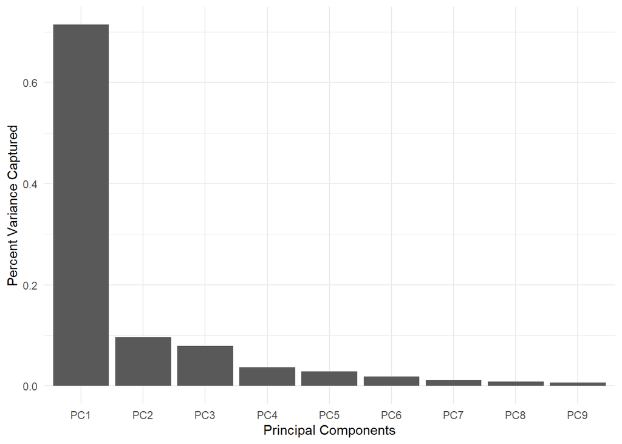

Screeplot of the HDI Data

```r
pc_names <- colnames(hdi_pca$rotation)

sd_vec=hdi_pca$sdev
variance_vec=sd_vec^2
prop_exp=variance_vec/sum(variance_vec)

# Use this data frame to make the screeplot
pct_expl_df <- data.frame(pc=pc_names,
                          pct_v=prop_exp,
                          v=variance_vec)

# Screeplot
ggplot(data=pct_expl_df,aes(x=pc,y=pct_v)) +
  geom_col()+
  theme_minimal()+
  labs(x="Principal Components",y="Percent Variance Captured")
```

We can use ggfortify to create a screeplot as well. This is a bit more automated, but less flexible. Great for diagnostics, but not for publication.

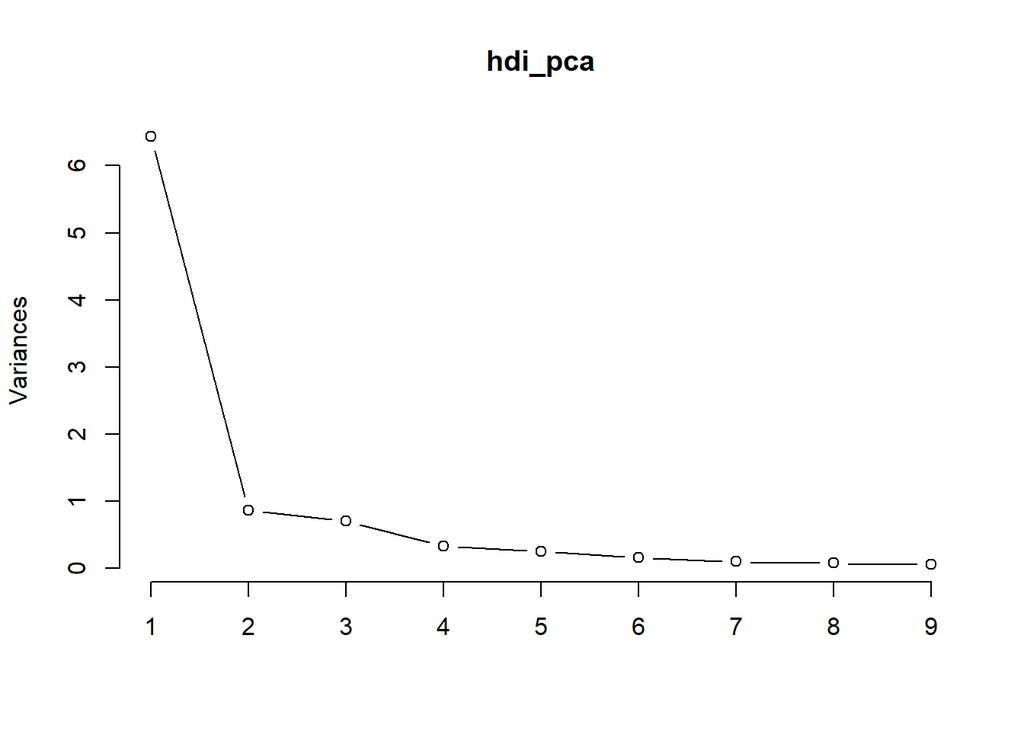

```r
# Variance explained by each PC
screeplot(hdi_pca, type = "lines")
```

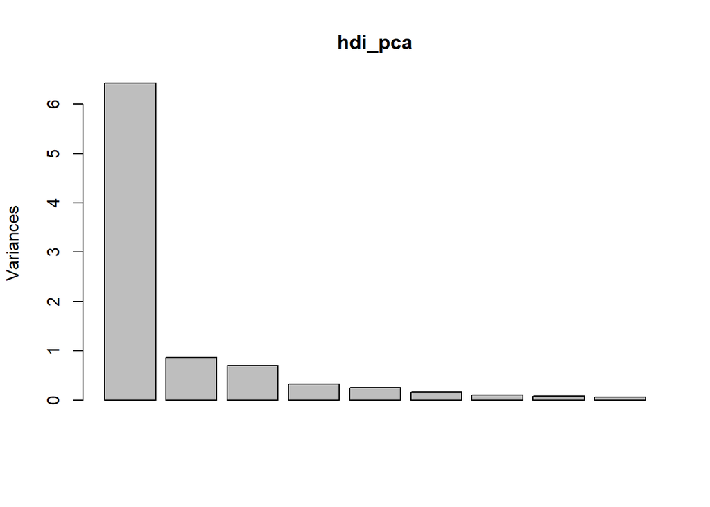

```r
screeplot(hdi_pca, type = "barplot")
```

## ggfortify autoplots

Autoplot can take a PCA object the original dataframe, and plot the observations in the new PC space. It can also plot the loadings of the variables. Run the code chunk first to see the biplot of HDI data.

One cool feature of ggfortify plots is that they follow the same graphics grammar after the initial plot is created. So you can add layers, change themes, etc. Clean up the biplot to make it more presentable. (Hint: use the data)

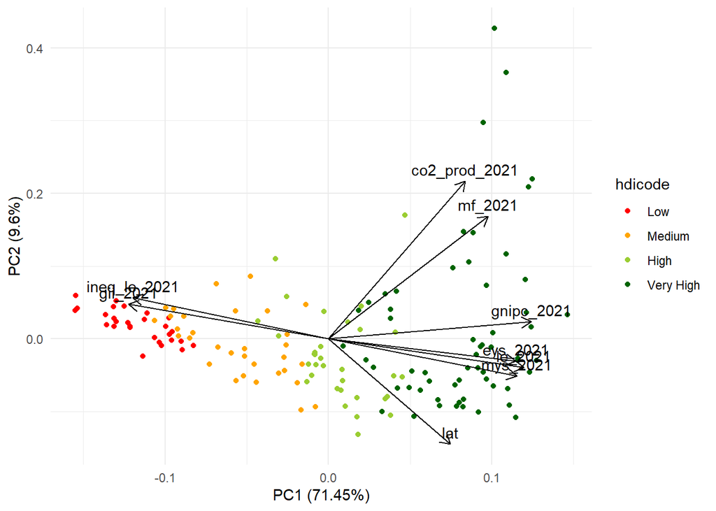

```r
autoplot(hdi_pca,
        data = hdi_data,
        loadings = TRUE,
        colour = 'hdicode',
        loadings.label = TRUE,
        loadings.colour = "black",
        loadings.label.colour = "black",
        loadings.label.vjust = -0.5
        ) +
  scale_color_manual(values = c('red', 'orange', 'yellowgreen', 'darkgreen')) +
  theme_minimal()
```

```r
# It's not perfect, but it's enough for now...
```

Complete the postlab exercise on your own. The data is stored in the data folder called `grazing_env.csv`. The data is from a study on the effects of grazing on soil properties.